# distributions_of_final_data

2023-08-13

```r
library(MASS)
library(knitr)
library(dplyr)
library(tidyverse)
library(gridExtra)
library(caret)
data <- read.csv('./our_data/new_stops.csv')
```

# Looking at the distributions of the final drivers dataset

### Average distance per stop

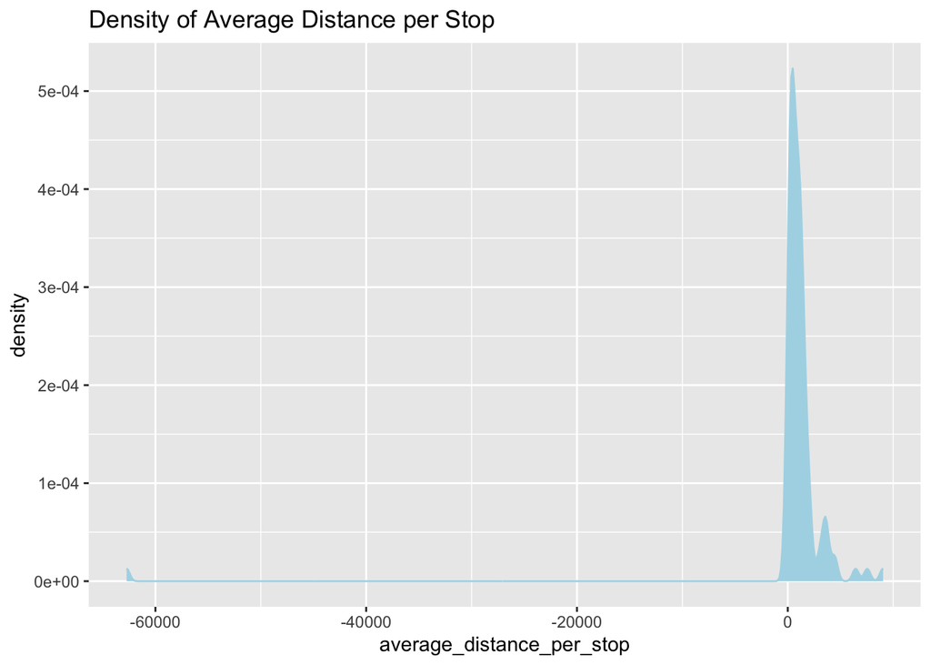

```r
data %>% ggplot(aes(x=average_distance_per_stop)) + geom_density(fill="lightblue", color="lightblue") + labs(title="Density of Average Distance per Stop")
```

Super NB: look at that weird spike in the negatives. Should investigate. Let me look at it as a boxplot:

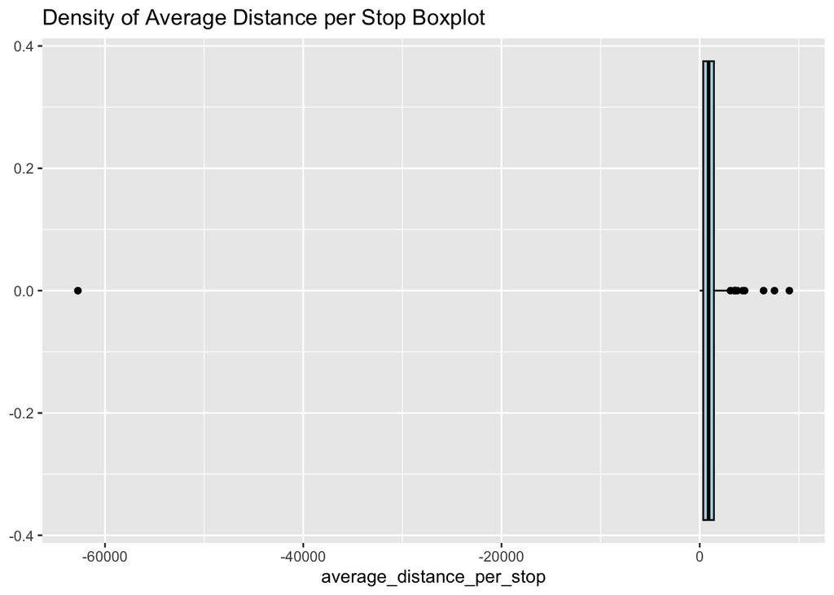

```r
data %>% ggplot(aes(x=average_distance_per_stop)) + geom_boxplot(fill="lightblue", color="black") + labs(title="Density of Average Distance per Stop Boxplot")
```

Let’s filter out that bottom neg values:

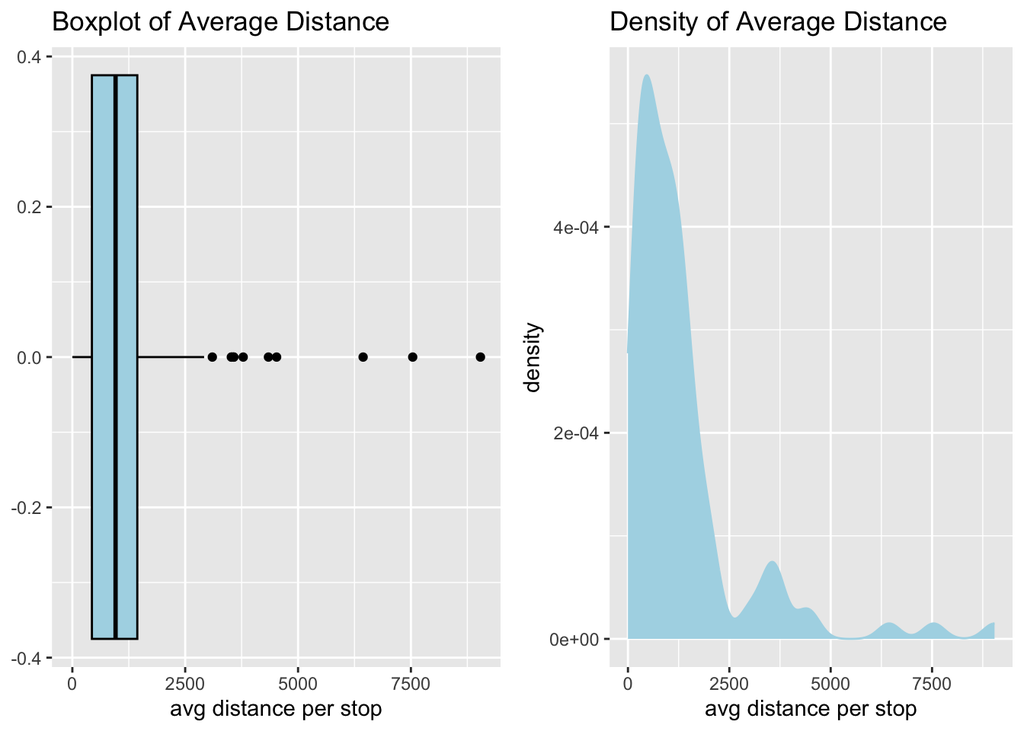

```r
plot1 <- data %>% filter(average_distance_per_stop > 0) %>% ggplot(aes(x=average_distance_per_stop)) + geom_boxplot(fill="lightblue", color="black") + labs(title="Boxplot of Average Distance", x = "avg distance per stop")
plot2 <- data %>% filter(average_distance_per_stop > 0) %>% ggplot(aes(x=average_distance_per_stop)) + geom_density(fill="lightblue", color="lightblue") + labs(title="Density of Average Distance", x = "avg distance per stop")
grid.arrange(plot1, plot2, ncol = 2, widths = c(3, 3))
```

Now that makes a lot more sense wow.

### Average number of Stops per day

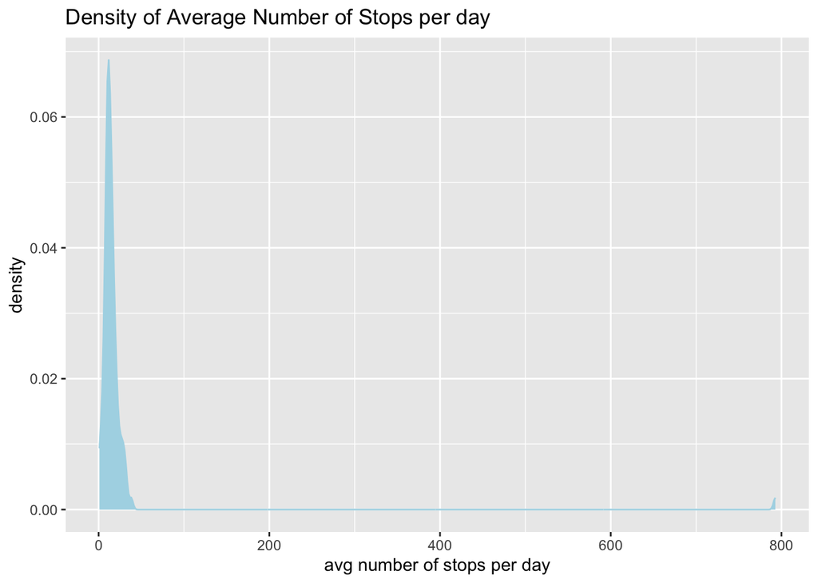

```r
data %>% ggplot(aes(x=average_number_of_stops_per_day)) + geom_density(fill="lightblue", color="lightblue") + labs(title="Density of Average Number of Stops per day", x = "avg number of stops per day")
```

Also NB: shoud look at that weird spike near 800 by making a boxplot of this dude

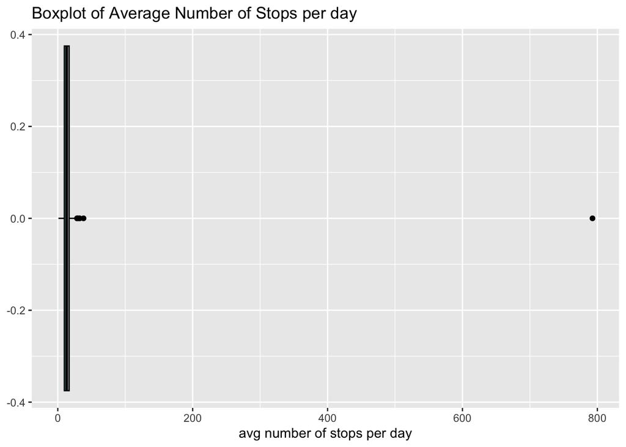

```r
data %>% ggplot(aes(x=average_number_of_stops_per_day)) + geom_boxplot(fill="lightblue", color="black") + labs(title="Boxplot of Average Number of Stops per day", x = "avg number of stops per day")
```

Ooh la, la. Look, that is a SINGLE outlier near 800. Let’s remove that dude as well. However, we should 100% investigate !!

## Looking at the average nmr of stops per day without outliers

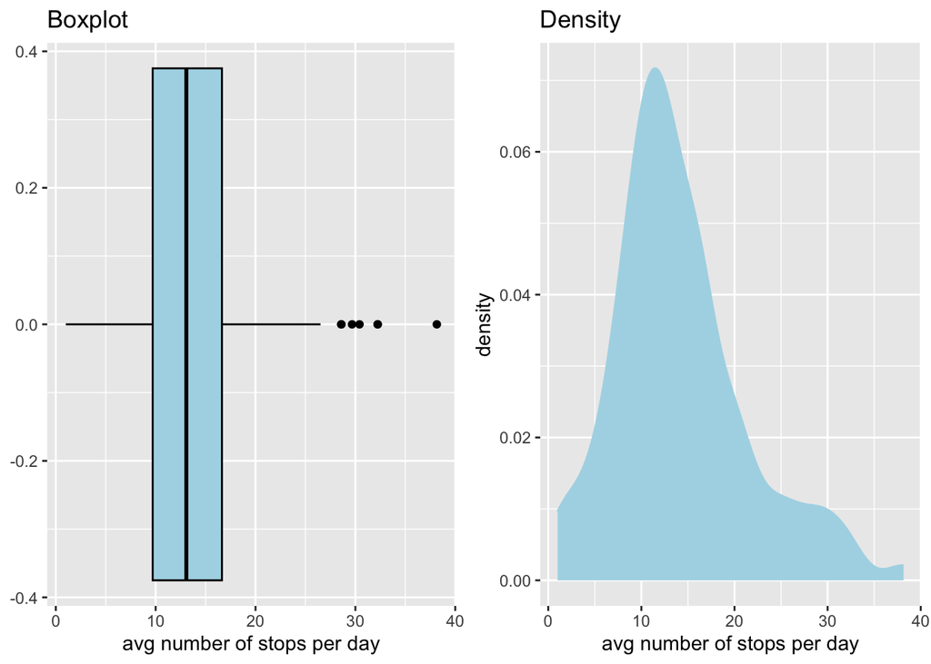

```r
plot1 <- data %>% filter(average_number_of_stops_per_day < 700) %>% ggplot(aes(x=average_number_of_stops_per_day)) + geom_boxplot(fill="lightblue", color="black") + labs(title="Boxplot", x = "avg number of stops per day")
plot2 <-  data %>% filter(average_number_of_stops_per_day < 700) %>% ggplot(aes(x=average_number_of_stops_per_day)) + geom_density(fill="lightblue", color="lightblue") + labs(title="Density", x = "avg number of stops per day")

grid.arrange(plot1, plot2, ncol = 2, widths = c(3, 3))
```

Now, those look tons better.

### Looking at the correlation between some things

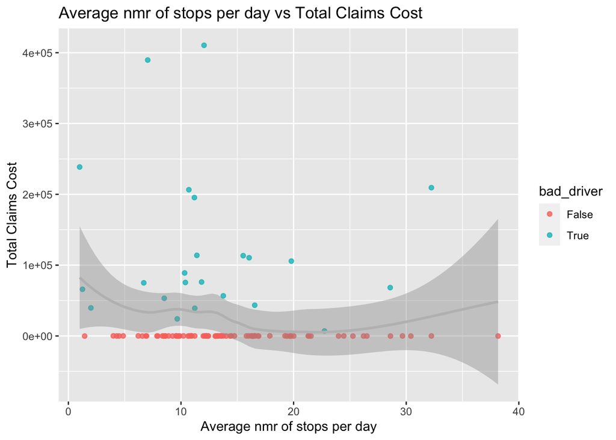

```r
data %>% filter(average_number_of_stops_per_day <700)  %>% ggplot(aes(x = average_number_of_stops_per_day, y = total_claims_cost)) + geom_jitter(aes(color=bad_driver), alpha=0.8) + labs(title="Average nmr of stops per day vs Total Claims Cost", x= "Average nmr of stops per day", y= "Total Claims Cost") + geom_smooth(color = "grey")
```

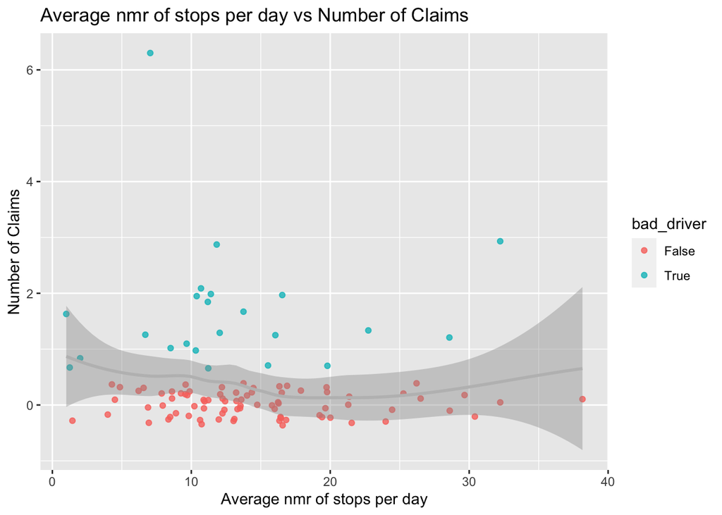

```r
data %>% filter(average_number_of_stops_per_day <700)  %>% ggplot(aes(x = average_number_of_stops_per_day, y = number_of_claims)) + geom_jitter(aes(color= bad_driver), alpha=0.8) + labs(title="Average nmr of stops per day vs Number of Claims", x= "Average nmr of stops per day", y= "Number of Claims") + geom_smooth(color = "grey")
```

### Total claims cost

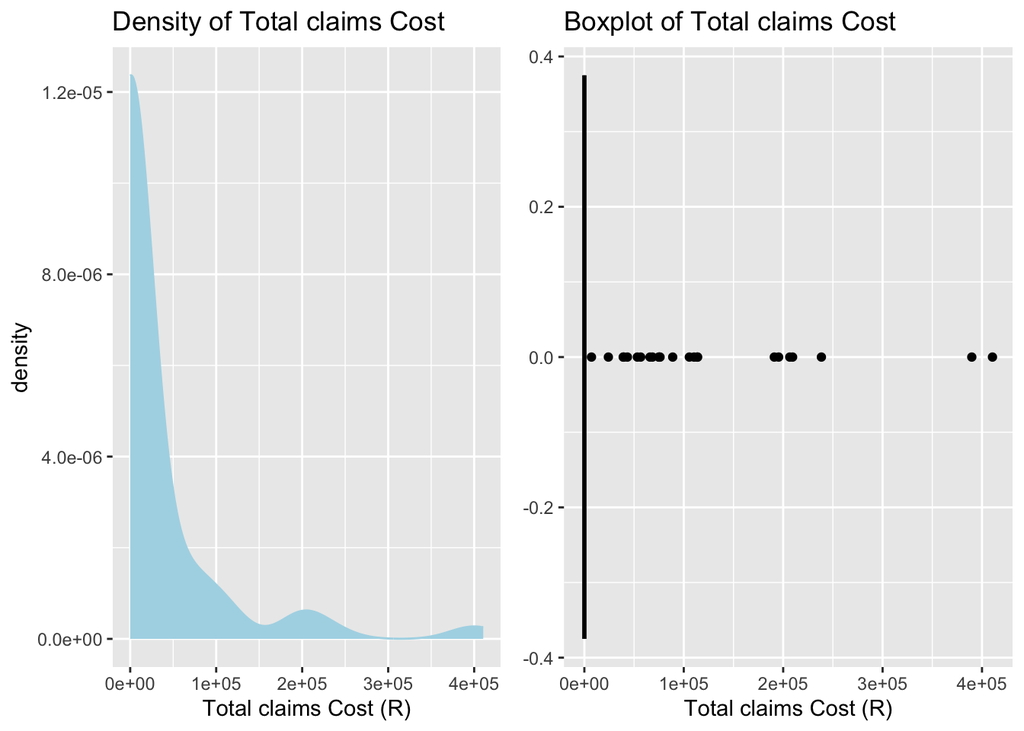

```r
plot1 <- data %>% ggplot(aes(x=total_claims_cost)) + geom_density(fill="lightblue", color="lightblue") + labs(title="Density of Total claims Cost", x = "Total claims Cost (R)")
plot2 <- data %>% ggplot(aes(x=total_claims_cost)) + geom_boxplot(fill="lightblue", color="black") + labs(title="Boxplot of Total claims Cost", x = "Total claims Cost (R)")

grid.arrange(plot1, plot2, ncol = 2, widths = c(3, 3))
```

Let us inspect that Boxplot a little more. I feel like the real density lies beyond all those 0’s.

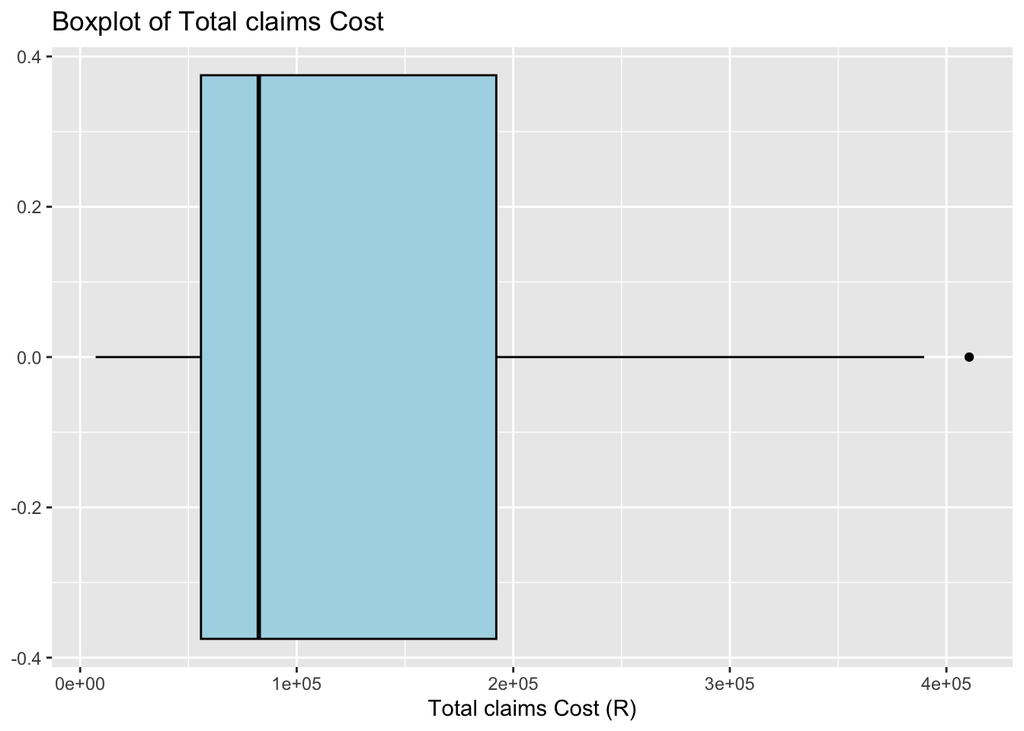

```r
data %>% filter(total_claims_cost > 0) %>% ggplot(aes(x=total_claims_cost)) + geom_boxplot(fill="lightblue", color="black") + labs(title="Boxplot of Total claims Cost", x = "Total claims Cost (R)")
```

A-Hah! Now that seems to look like a density. Look at that one dude wth R4 0000 +, that is sort of hectic.

### Over speed limit

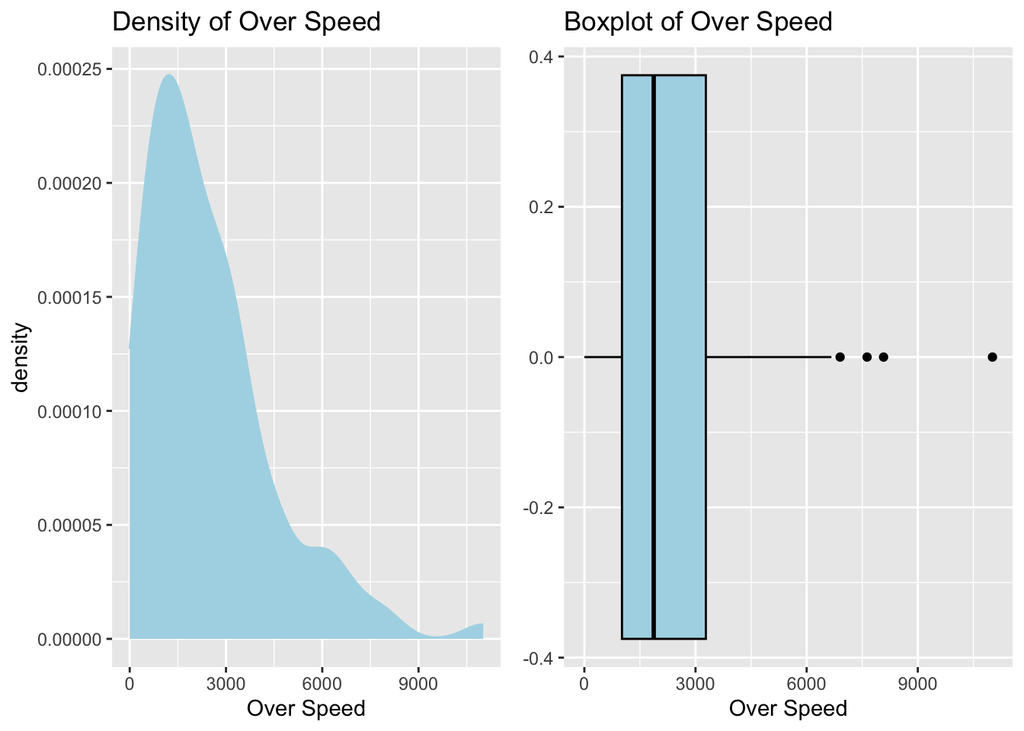

```r
plot1 <- data %>% ggplot(aes(x=overSpeed)) + geom_density(fill="lightblue", color="lightblue") + labs(title="Density of Over Speed", x = "Over Speed")
plot2 <- data %>% ggplot(aes(x=overSpeed)) + geom_boxplot(fill="lightblue", color="black") + labs(title="Boxplot of Over Speed", x = "Over Speed")

grid.arrange(plot1, plot2, ncol = 2, widths = c(3, 3))
```

We should probably go look at those guys that have 9000x over the speed limit

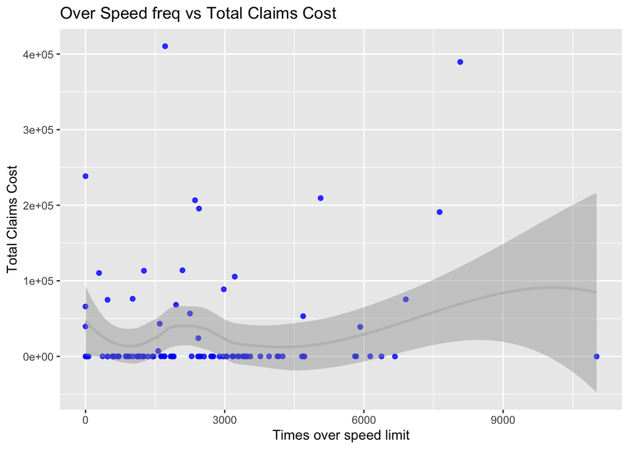

```r
data %>% ggplot(aes(x = overSpeed, y = total_claims_cost)) + geom_jitter(color= "blue", alpha=0.8) + labs(title="Over Speed freq vs Total Claims Cost", x= "Times over speed limit", y= "Total Claims Cost") + geom_smooth(color = "grey")
```

Ok, but those total_claims = 0 are annoying things. Let’s filter them out.

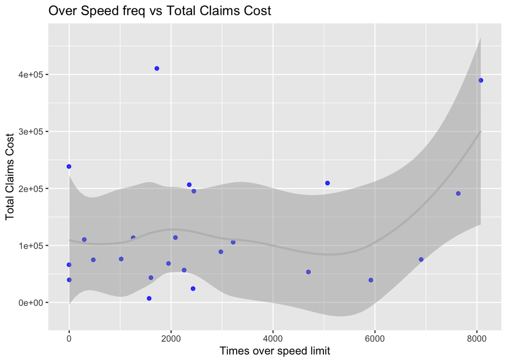

```r
data %>% filter(total_claims_cost > 0) %>% ggplot(aes(x = overSpeed, y = total_claims_cost)) + geom_jitter(color= "blue", alpha=0.8) + labs(title="Over Speed freq vs Total Claims Cost", x= "Times over speed limit", y= "Total Claims Cost") + geom_smooth(color = "grey")
```

Ok, this is still weird. I don’t think this actually has a proper effect.

## Normal Braking

```r
plot11 <- data %>% ggplot(aes(x=normal_braking)) + geom_density(fill="lightblue", color="lightblue") + labs(title="Density Normal Braking", x = "Normal Braking")
plot12 <- data %>% ggplot(aes(x=normal_braking)) + geom_boxplot(fill="lightblue", color="black") + labs(title="Boxplot Normal Braking", x = "Normal Braking")
```

## Emergency Braking

```r
plot21 <- data %>% ggplot(aes(x=emergency_braking)) + geom_density(fill="lightblue", color="lightblue") + labs(title="Density Emergency Braking", x = "Emergency Braking")
plot22 <- data %>% ggplot(aes(x=emergency_braking)) + geom_boxplot(fill="lightblue", color="black") + labs(title="Boxplot Emergency Braking", x = "Emergency Braking")
```

## Harsh Braking

```r
plot31 <- data %>% ggplot(aes(x=harsh_braking)) + geom_density(fill="lightblue", color="lightblue") + labs(title="Density Harsh Braking", x = "Harsh Braking")
plot32 <- data %>% ggplot(aes(x=harsh_braking)) + geom_boxplot(fill="lightblue", color="black") + labs(title="Boxplot Harsh Braking", x = "Harsh Braking")
```

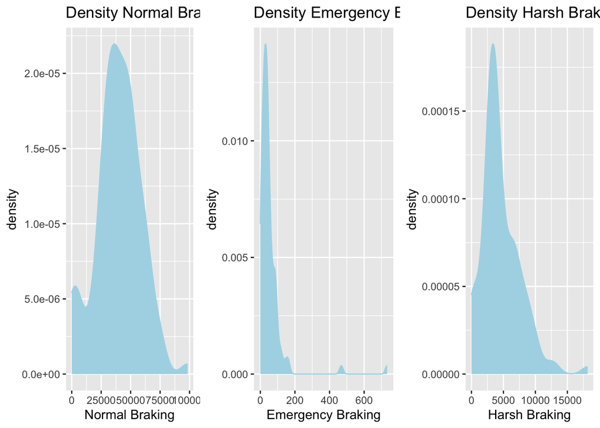

```r
grid.arrange(plot11, plot21,plot31, ncol = 3)
```

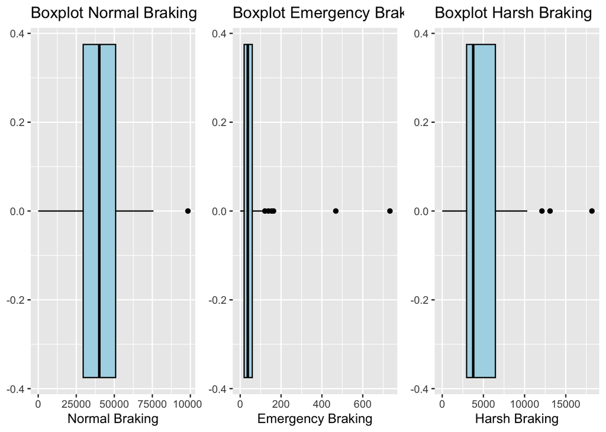

```r
grid.arrange(plot12, plot22,plot32, ncol = 3)
```

### Some speculative plotting

1. Relationship between overspeed and nmr stops (Surely??)

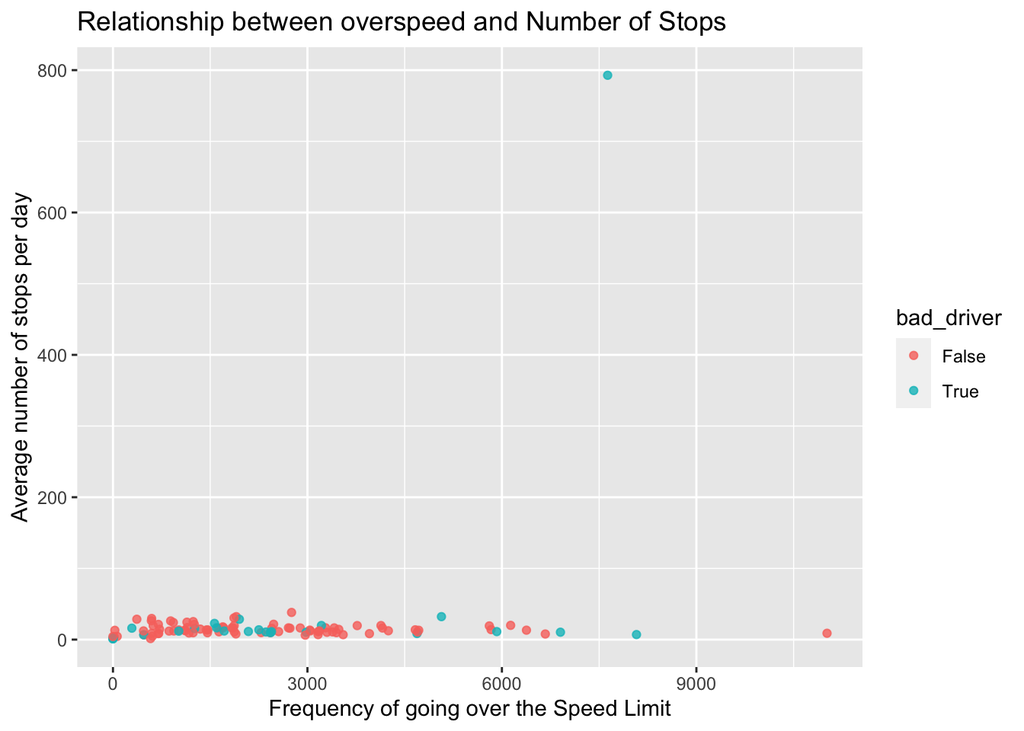

```r
data %>% ggplot(aes(x=overSpeed, y=average_number_of_stops_per_day, color=bad_driver)) + geom_jitter(alpha=0.8)  + labs(title="Relationship between overspeed and Number of Stops", x= "Frequency of going over the Speed Limit", y="Average number of stops per day")
```

Ai, that outlier again.

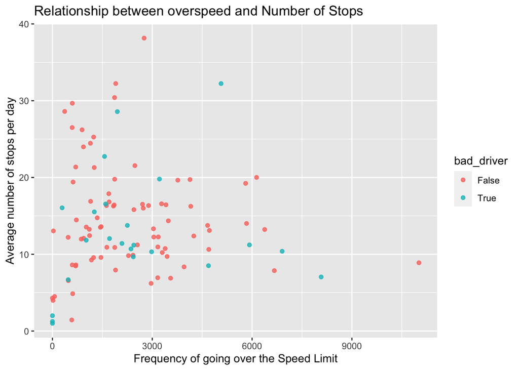

```r
data %>% filter(average_number_of_stops_per_day < 700) %>% ggplot(aes(x=overSpeed, y=average_number_of_stops_per_day, color=bad_driver)) + geom_jitter(alpha=0.8)  + labs(title="Relationship between overspeed and Number of Stops", x= "Frequency of going over the Speed Limit", y="Average number of stops per day")
```

Wow, ok. Literally no correlation. Whoops.

## Municipalities

```r
muni <- read.csv('./our_data/muni.csv')
munic <- muni %>% select(Municipality) %>% unique() %>% unlist()
muni_data <- muni %>% group_by(Municipality) %>% summarise(
  "Avg nmr Stops" = mean(average_number_of_stops_per_day),
  "Avg dist per Stop" = mean(average_distance_per_stop),
  "Avg claim cost" = mean(total_claims_cost),
  "Avg nmr claims" = mean(number_of_claims),
  "Avg times OverSpeed"  = mean(overSpeed)
)
```

Looking at their claim costs

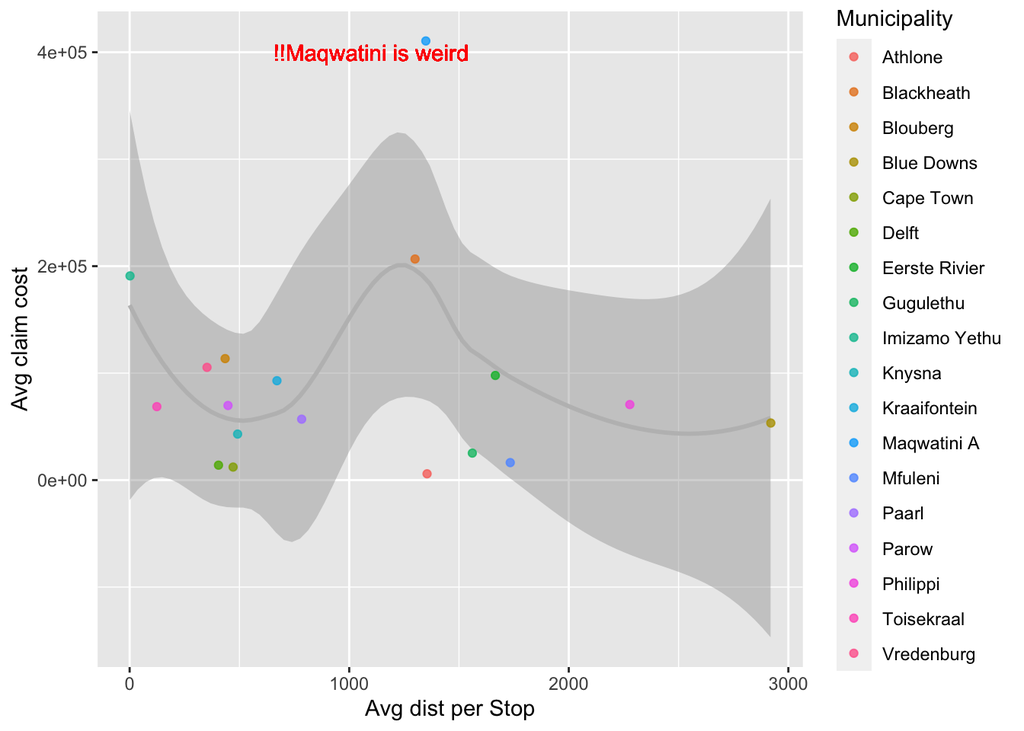

```r
muni_data %>% filter(`Avg claim cost` >0) %>% filter(`Avg dist per Stop` >0) %>% ggplot(aes(color=Municipality, y=`Avg claim cost`, x = `Avg dist per Stop`)) + geom_smooth(color="grey")+ geom_jitter( alpha=0.8) +  geom_text(aes(x = 1100, y = 4e+05, label = "!!Maqwatini is weird"), color = "red")
```

```r
set.seed(123)  # For reproducibility
train_index <- createDataPartition(muni$bad_driver, p = 0.8, list = FALSE)
train_data <- data[train_index, ]
test_data <- data[-train_index, ]
```

```r
encoded_train_data <- as.data.frame(predict(dummyVars(~., train_data), newdata = train_data))
encoded_test_data <- as.data.frame(predict(dummyVars(~., train_data), newdata = test_data))

encoded_train_data <- encoded_train_data[, -which(names(encoded_train_data) == "bad_driverFalse")]
encoded_test_data <- encoded_test_data[, -which(names(encoded_test_data) == "bad_driverFalse")]
```

```r
lda_model <- lda(bad_driverTrue ~ ., data = encoded_train_data)

# Use the trained LDA model to predict the class labels for the testing set
predicted_class_labels <- predict(lda_model, newdata = encoded_test_data)

# Extract the predicted class labels
predicted_labels <- predicted_class_labels$class

accuracy <- sum(predicted_labels == encoded_test_data$bad_driver) / length(encoded_test_data$bad_driver)
print(accuracy)
```

```
## [1] 0.95
```